# lab3markdown

2022-09-13

## Task 1

```r
getwd()
```

```
## [1] "C:/MATH4753/Labs/Lab3"
```

## Task 2

```r
spruce <- read.csv("SPRUCE.csv")
head(spruce)
```

```
##   BHDiameter Height
## 1       18.9   20.0
## 2       16.6   18.8
## 3       15.5   16.8
## 4       15.5   16.9
## 5       19.4   20.2
## 6       13.7   16.3
```

## Task 3

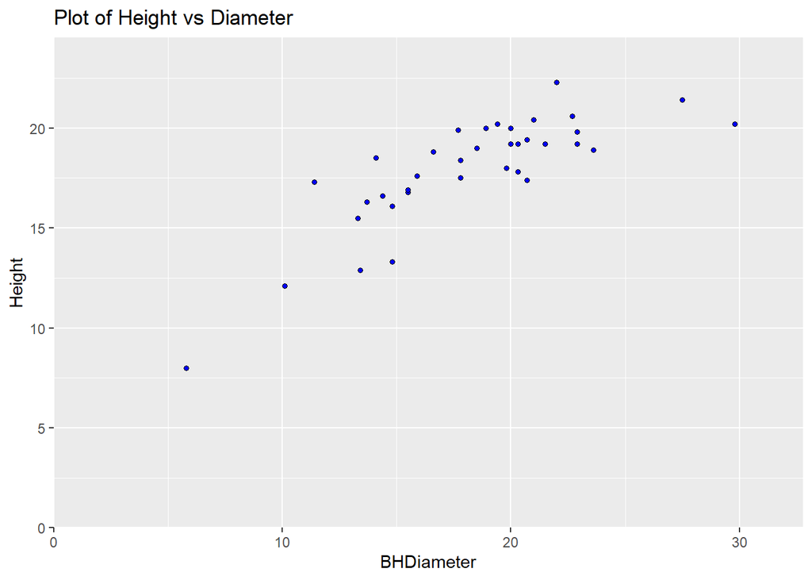

```r
spruce <- read.csv("SPRUCE.csv")

library(ggplot2)

ggplot(aes(x = BHDiameter, y = Height), data = spruce) + geom_point(shape=21, fill="blue", size=1.2) + ggtitle("Plot of Height vs Diameter") + scale_x_continuous(expand = c(0, 0), limits = c(0, 1.1*max(spruce$BHDiameter))) +
  scale_y_continuous(expand = c(0, 0), limits = c(0, 1.1*max(spruce$Height)))
```

Does there appear to be a straight line relationship?

Almost, but the graph begins to curve when diameter is about 17cm.

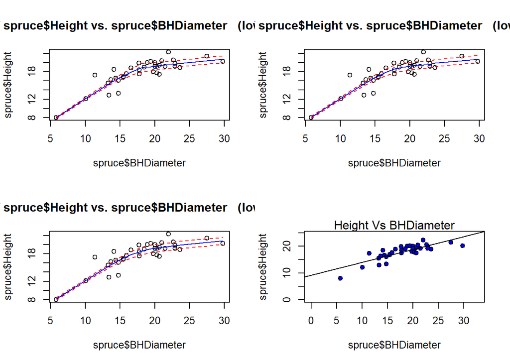

```r
library(s20x)

layout(matrix(1:4,nr=2,nc=2,byrow=TRUE))
trendscatter(spruce$Height~spruce$BHDiameter,f=.5)
trendscatter(spruce$Height~spruce$BHDiameter,f=.6)
trendscatter(spruce$Height~spruce$BHDiameter,f=.7)
plot(spruce$Height~spruce$BHDiameter,bg="Blue",pch=21,ylim=c(0,1.1*max(Height)),xlim=c(0,1.1*max(BHDiameter)), data=spruce)
mtext("Height Vs BHDiameter",side=3)
spruce.lm = with(spruce, lm(Height~BHDiameter))
abline(spruce.lm)
```

These plots clearly show that the straight line is not appropriate. It is fails to model the change in slope that occurs.

## Task 4

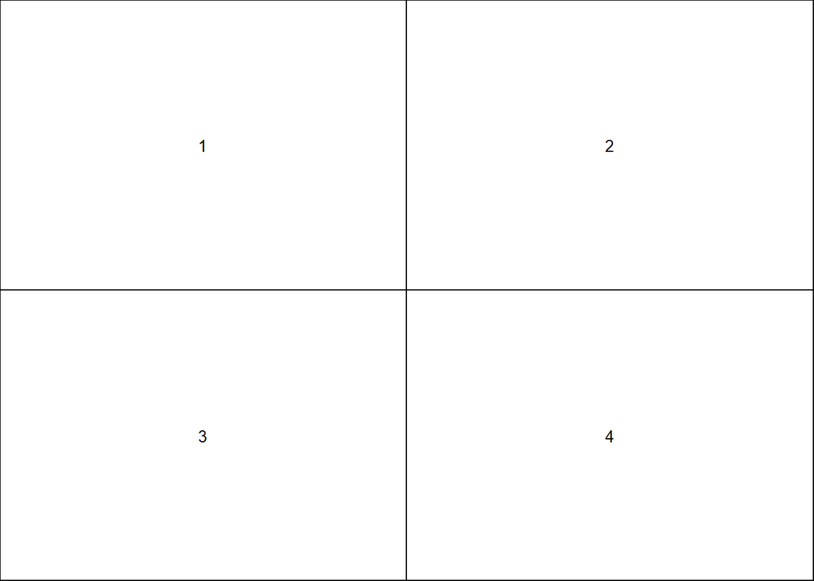

```r
layout(matrix(1:4,nr=2,nc=2,byrow=TRUE))
layout.show(4)
```

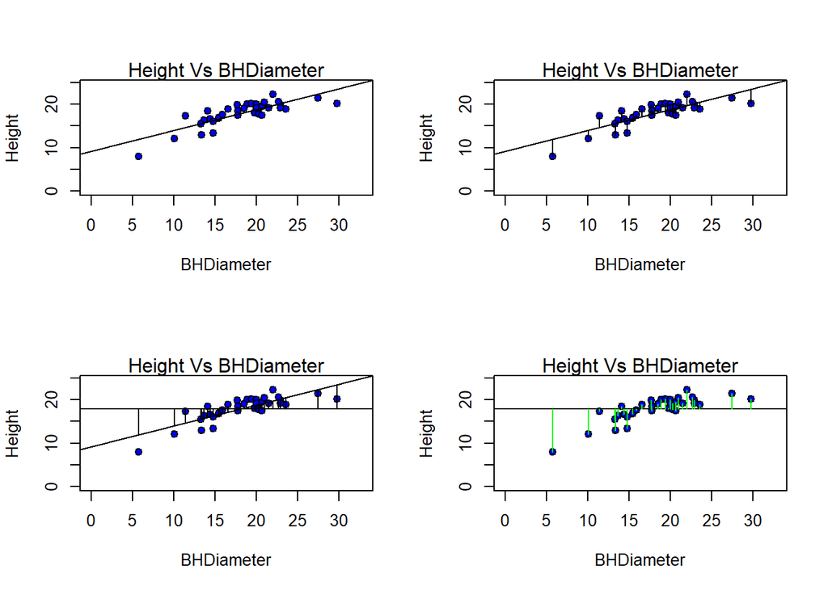

```r
spruce.lm = with(spruce, lm(Height~BHDiameter))

plot(Height~BHDiameter,bg="Blue",pch=21,ylim=c(0,1.1*max(Height)),xlim=c(0,1.1*max(BHDiameter)), data=spruce)
abline(spruce.lm)
mtext("Height Vs BHDiameter",side=3)

yhat=fitted(spruce.lm)

plot(Height~BHDiameter,bg="Blue",pch=21,ylim=c(0,1.1*max(Height)),xlim=c(0,1.1*max(BHDiameter)), data=spruce)
with(spruce,{
  segments(BHDiameter,Height,BHDiameter,yhat)
})
abline(spruce.lm)
mtext("Height Vs BHDiameter",side=3)

plot(Height~BHDiameter,bg="Blue",pch=21,ylim=c(0,1.1*max(Height)),xlim=c(0,1.1*max(BHDiameter)), data=spruce)
with(spruce,{
  segments(BHDiameter,mean(Height),BHDiameter,yhat)
})
with(spruce, abline(h=mean(Height)))
abline(spruce.lm)
mtext("Height Vs BHDiameter",side=3)

plot(Height~BHDiameter,bg="Blue",pch=21,ylim=c(0,1.1*max(Height)),xlim=c(0,1.1*max(BHDiameter)), data=spruce)
with(spruce,abline(h=mean(Height)))
with(spruce, segments(BHDiameter,Height,BHDiameter,mean(Height),col="Green"))
mtext("Height Vs BHDiameter",side=3)
```

```r
RSS=with(spruce,sum((Height-yhat)^2))
RSS
```

```
## [1] 95.70281
```

```r
MSS=with(spruce,sum((yhat-mean(Height))^2))
MSS
```

```
## [1] 183.2447
```

```r
TSS=with(spruce,sum((Height-mean(Height))^2))
TSS
```

```
## [1] 278.9475
```

```r
MSS/TSS
```

```
## [1] 0.6569146
```

```r
TSS
```

```
## [1] 278.9475
```

```r
MSS + RSS
```

```
## [1] 278.9475
```

MSS/TSS is the model sum of squares divided by the total sum of squares. This value tells us how accurate our model is compared to the actual data, where a number closer to 1 is better. This is also called the coefficient of determination.

TSS does equal MSS + RSS

## Task 5

```r
spruce.lm = with(spruce, lm(Height~BHDiameter))
summary(spruce.lm)
```

```
##
## Call:
## lm(formula = Height ~ BHDiameter)
##
## Residuals:
##     Min      1Q  Median      3Q     Max
## -3.9394 -0.9763  0.2829  0.9950  2.6644
##
## Coefficients:
##             Estimate Std. Error t value Pr(>|t|)
## (Intercept)  9.14684    1.12131   8.157 1.63e-09 ***
## BHDiameter   0.48147    0.05967   8.069 2.09e-09 ***
## ---
## Signif. codes:  0 '***' 0.001 '**' 0.01 '*' 0.05 '.' 0.1 ' ' 1
##
## Residual standard error: 1.678 on 34 degrees of freedom
## Multiple R-squared:  0.6569, Adjusted R-squared:  0.6468
## F-statistic:  65.1 on 1 and 34 DF,  p-value: 2.089e-09
```

```r
coef(spruce.lm)
```

```
## (Intercept)  BHDiameter
##   9.1468390   0.4814743
```

Slope is .48147.

The intercept value is 9.14684.

The equation of the fitted line is Height = .48147*BHDiameter + 9.14684

```r
predict(spruce.lm, data.frame(BHDiameter=c(15,18,20)))
```

```
##        1        2        3
## 16.36895 17.81338 18.77632
```

The predicted values for BHDiameter = 15, 18, and 20 cm are respectively 16.36895 17.81338 18.77632.

## Task 6

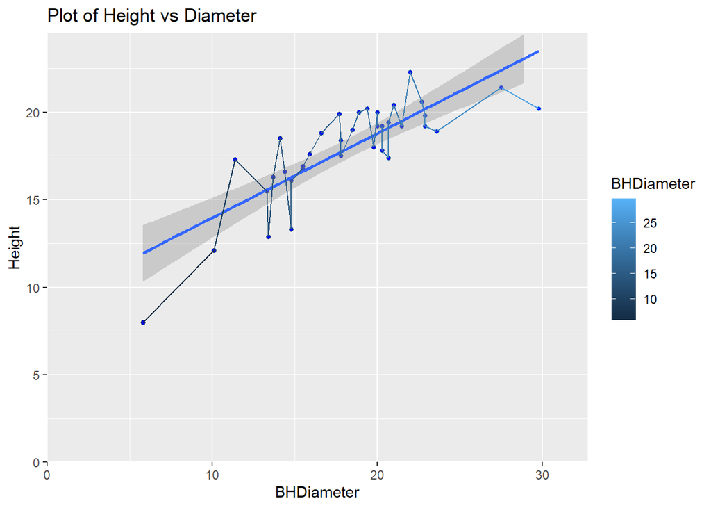

```r
ggplot(aes(x = BHDiameter, y = Height, colour = BHDiameter), data = spruce) + geom_point(shape=21, fill="blue", size=1.2) + ggtitle("Plot of Height vs Diameter") + scale_x_continuous(expand = c(0, 0), limits = c(0, 1.1*max(spruce$BHDiameter))) +
  scale_y_continuous(expand = c(0, 0), limits = c(0, 1.1*max(spruce$Height))) + geom_smooth(method="lm")+geom_line()
```

## Task 7

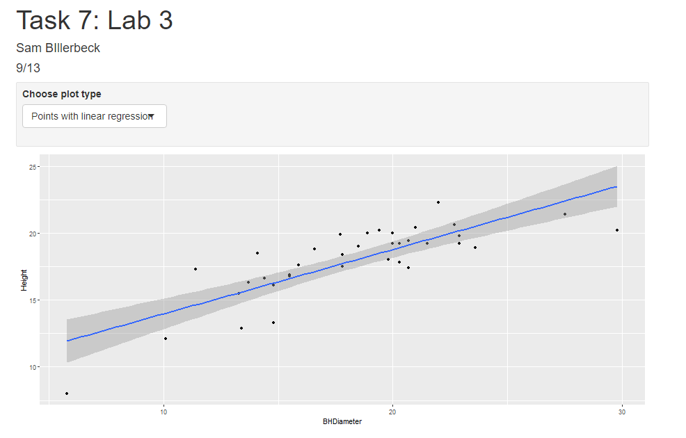

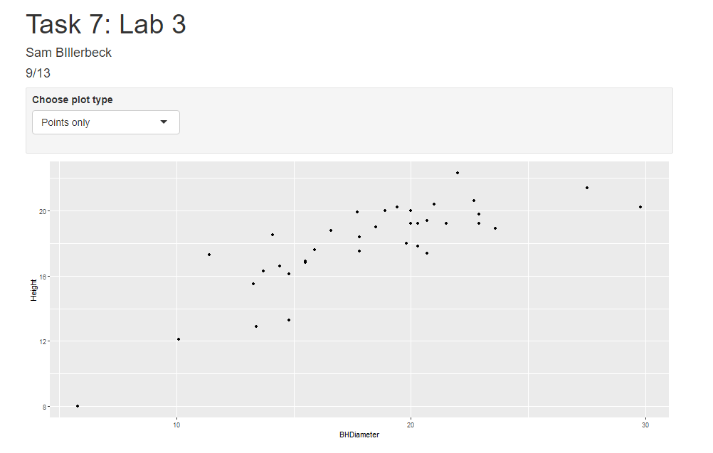

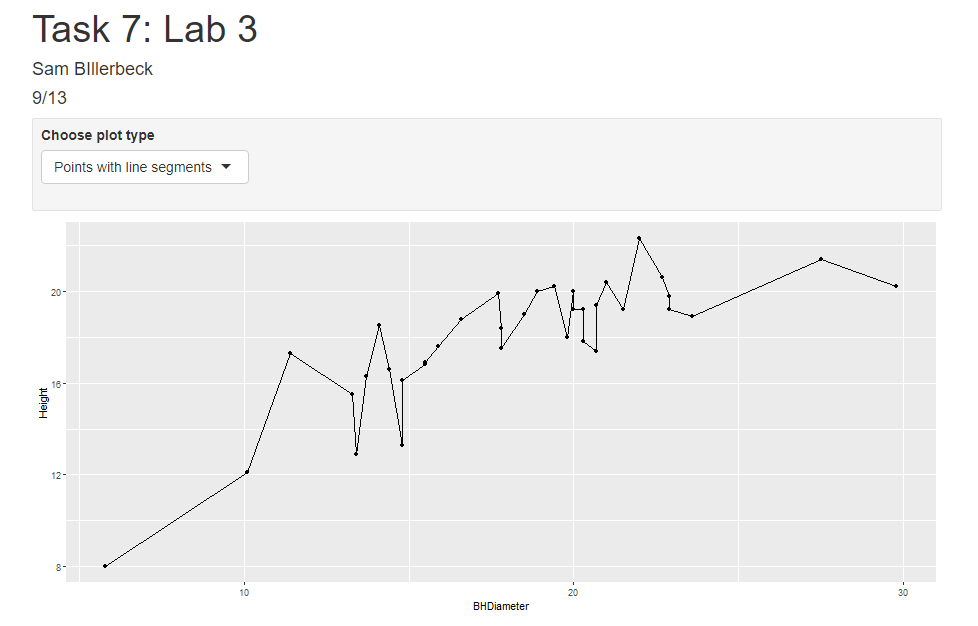

Code used for task 7:

library(ggplot2)

spruce.df = read.csv(“SPRUCE.csv”)#MS pg478

inputPanel(

selectInput(“plotg”, “Choose plot type”, list(`points` = c(“Points only”, “Points with linear regression”, “Points with line segments”) ) ) )

renderPlot({

g = ggplot(spruce.df, aes(x = BHDiameter, y = Height)) + geom_point()

gsh = g + geom_point() + geom_smooth(method=“lm”)

gsr = g + geom_point() + geom_line()

if(input$plotg == “Points only”) print(g)

if(input$plotg == “Points with linear regression”) print(gsh)

if(input$plotg == “Points with line segments”) print(gsr)

})